# Fake News Detection Using Machine Learning

**A Project Report Submitted in Partial Fulfillment of the Requirements**

**for the Award of the Degree of**

### Computer Science and Engineering

**Submitted by:**

**Under the Guidance of:**

Department of Computer Science and Engineering

**Department of Computer Science and Engineering**

**Academic Year 2025–2026**

# CERTIFICATE

The project has been completed under the supervision of the undersigned and is found to be satisfactory.

[output not shown]

| **External Examiner** |
| --- |
| Name & Signature |

**Date:** March 2026

# DECLARATION

I further declare that this project report or any part of it has not been submitted earlier to any other University or Institution for the award of any degree or diploma.

**Date:** March 2026

B.Tech CSE

# ACKNOWLEDGEMENT

I extend my heartfelt thanks to the Principal of our institution for providing an environment conducive to academic excellence and research.

I am also grateful to all the faculty members of the Department of Computer Science and Engineering for their continuous encouragement and valuable suggestions during various phases of this project.

I sincerely thank my classmates and friends who supported me throughout this project with their constructive criticism, suggestions, and cooperation. Their discussions and insights helped shape and refine many aspects of this work.

I would also like to acknowledge the open-source community and the developers of Python, scikit-learn, NLTK, Flask, and other libraries used in this project. The availability of high-quality open-source tools was instrumental in the successful implementation of this system.

Finally, I wish to express my profound gratitude to my parents and family members for their unwavering support, patience, and encouragement throughout my academic journey. Their belief in my abilities and constant motivation have been the driving force behind the completion of this project.

# ABSTRACT

The rapid proliferation of fake news and misinformation across digital platforms has emerged as one of the most pressing challenges of the modern information age. The widespread availability of social media, online news portals, and messaging platforms has created an environment where false information can be generated, disseminated, and consumed at an unprecedented scale and speed. This phenomenon poses serious threats to democratic processes, public health responses, financial markets, and social cohesion.

This project presents a comprehensive **Fake News Detection System** that leverages **Natural Language Processing (NLP)** techniques and **Machine Learning** algorithms to automatically classify news articles as either genuine or fabricated. The system implements a complete pipeline that encompasses data collection, text preprocessing, feature extraction, model training, evaluation, and deployment as a web-based application.

The core methodology involves several key stages. First, text data undergoes extensive preprocessing including removal of special characters, conversion to lowercase, tokenization, stopword removal, and stemming using the Porter Stemmer algorithm. The preprocessed text is then transformed into numerical feature vectors using **Term Frequency–Inverse Document Frequency (TF-IDF)** vectorization with n-gram features (unigrams, bigrams, and trigrams) and a maximum feature limit of 5,000 dimensions.

The system was deployed as an interactive web application using the **Flask** micro-framework, providing users with a simple and intuitive interface to input news text and receive instant classification results. The application features a clean Bootstrap-based user interface and provides clear visual indicators for the classification outcome.

**Keywords:** Fake News Detection, Machine Learning, Natural Language Processing, TF-IDF, Passive Aggressive Classifier, Text Classification, Flask Web Application, NLP Pipeline, Misinformation Detection

| Chapter | Title | Page |
| --- | --- | --- |
|  | Certificate | i |
|  | Declaration | ii |
|  | Acknowledgement | iii |
|  | Abstract | iv |
|  | Table of Contents | v |
|  | List of Figures | vii |
|  | List of Tables | viii |
| **1** | **Introduction** | **1** |
| 1.1 | Background and Motivation | 1 |
| 1.2 | Definition of Fake News | 2 |
| 1.3 | Impact of Fake News | 2 |
| 1.4 | Need for Automated Detection | 3 |
| 1.5 | Objectives of the Project | 3 |
| 1.6 | Scope of the Project | 4 |
| 1.7 | Organization of the Report | 4 |
| **2** | **Literature Review** | **5** |
| 2.1 | Knowledge-Based Approaches | 5 |
| 2.2 | Machine Learning Approaches | 6 |
| 2.3 | Deep Learning Approaches | 7 |
| 2.4 | Hybrid and Ensemble Methods | 8 |
| 2.5 | Feature Engineering Techniques | 8 |
| 2.6 | Existing Tools and Platforms | 9 |
| 2.7 | Research Gaps and Motivation | 9 |
| **3** | **Problem Statement and Objectives** | **10** |
| 3.1 | Problem Definition | 10 |
| 3.2 | Objectives | 10 |
| 3.3 | Proposed Solution | 11 |
| **4** | **System Architecture and Design** | **12** |
| 4.1 | High-Level Architecture | 12 |
| 4.2 | Data Flow Diagram | 13 |
| 4.3 | UML Use Case Diagram | 13 |
| 4.4 | Component Design | 14 |
| 4.5 | Technology Stack | 14 |
| **5** | **Dataset Description and Analysis** | **15** |
| 5.1 | Kaggle Fake News Dataset | 15 |
| 5.2 | LIAR Dataset | 16 |
| 5.3 | Dataset Statistics and Exploration | 17 |
| 5.4 | Data Quality Assessment | 18 |
| **6** | **Methodology** | **19** |
| 6.1 | Data Preprocessing Pipeline | 19 |
| 6.2 | Feature Extraction Using TF-IDF | 20 |
| 6.3 | Machine Learning Algorithms | 21 |
| 6.4 | Deep Learning with LSTM | 23 |
| 6.5 | Model Selection and Hyperparameters | 24 |
| **7** | **Implementation** | **25** |
| 7.1 | Development Environment | 25 |
| 7.2 | Data Loading and Preprocessing Code | 25 |
| 7.3 | Model Training Code | 26 |
| 7.4 | Flask Web Application | 27 |
| 7.5 | Frontend Design | 28 |
| **8** | **Results and Evaluation** | **29** |
| 8.1 | Model Performance Metrics | 29 |
| 8.2 | Confusion Matrix Analysis | 30 |
| 8.3 | Model Comparison | 31 |
| 8.4 | Web Application Testing | 32 |
| 8.5 | User Testing with Real and Fake Samples | 33 |
| **9** | **Conclusion and Future Work** | **35** |
| 9.1 | Summary of Contributions | 35 |
| 9.2 | Limitations | 36 |
| 9.3 | Future Enhancements | 36 |
| **10** | **References** | **37** |
|  | **Appendices** | **39** |
| A.1 | Complete Source Code Listings | 39 |
| A.2 | Requirements and Dependencies | 40 |

# LIST OF FIGURES

[output not shown]

# LIST OF TABLES

| Table No. | Title | Page |
| --- | --- | --- |
| Table 4.1 | Technology stack description | 14 |
| Table 5.1 | Kaggle dataset feature summary | 15 |
| Table 5.2 | LIAR dataset label distribution | 16 |
| Table 5.3 | Dataset statistics comparison | 16 |
| Table 5.4 | Subject-wise article count | 17 |
| Table 6.1 | TF-IDF hyperparameters | 21 |
| Table 6.2 | Machine learning algorithm comparison | 24 |
| Table 8.1 | Classification report — Passive Aggressive Classifier | 29 |
| Table 8.2 | Confusion matrix values | 30 |
| Table 8.3 | Model accuracy comparison | 31 |
| Table 8.4 | User testing results — Real news samples | 34 |
| Table 8.5 | User testing results — Fake news samples | 34 |
| Table 8.6 | Comparison with related work | 35 |

# Chapter 1: Introduction

## 1.1 Background and Motivation

The digital revolution has fundamentally transformed how information is created, shared, and consumed across the globe. With the advent of social media platforms such as Facebook, Twitter (now X), Instagram, and WhatsApp, along with countless online news portals and blogging platforms, the barriers to publishing and disseminating information have been virtually eliminated. While this democratization of information has brought numerous benefits — including greater access to diverse viewpoints, faster news dissemination, and enhanced public discourse — it has also created fertile ground for the spread of misinformation and disinformation.

Fake news, broadly defined as deliberately fabricated information presented as legitimate news, has emerged as one of the most significant challenges of the modern information ecosystem. The term gained widespread public attention during the 2016 United States presidential election, when numerous fabricated news stories were shared millions of times on social media platforms, potentially influencing public opinion and electoral outcomes. Since then, the problem has only intensified, with fake news playing a significant role in public discourse around the world.

The consequences of fake news are far-reaching and deeply concerning. During the COVID-19 pandemic, the World Health Organization coined the term "infodemic" to describe the overwhelming flood of information — both accurate and inaccurate — that accompanied the health crisis. Misinformation about treatments, vaccines, and the origins of the virus spread rapidly through social media channels, potentially contributing to vaccine hesitancy, the use of dangerous unproven treatments, and non-compliance with public health measures. Studies have estimated that exposure to COVID-19 misinformation was associated with a significant decrease in vaccination intent among affected populations.

Beyond public health, fake news has been implicated in inciting violence, manipulating financial markets, undermining trust in democratic institutions, and exacerbating social divisions. The economic impact is also substantial — a study by the University of Baltimore estimated that fake news costs the global economy approximately $78 billion annually, including costs related to stock market losses, cybersecurity threats, and reputational damage to organizations.

The sheer volume and velocity of information sharing on digital platforms make manual fact-checking impractical as a sole solution. While organizations such as Snopes, PolitiFact, and Full Fact perform valuable work in verifying claims and debunking falsehoods, they can only address a small fraction of the misinformation circulating online. This reality has motivated significant research into automated approaches for detecting fake news, leveraging advances in natural language processing (NLP), machine learning (ML), and artificial intelligence (AI).

This project is motivated by the urgent need for effective, scalable, and accessible tools for automated fake news detection. By developing a system that can quickly analyze and classify news articles, we aim to contribute to the broader effort of combating misinformation and protecting the integrity of public discourse.

## 1.2 Definition of Fake News

Fake news encompasses several distinct categories of problematic content, each with different characteristics and motivations:

- **Fabricated Content:** Entirely fictitious articles that are designed to deceive and have no basis in fact. These are created from scratch with the intent to mislead readers.
- **Manipulated Content:** Genuine information or imagery that has been altered or distorted to create a false narrative. This includes selectively edited quotes, doctored images, and out-of-context statistics.
- **Satire/Parody Misinterpreted:** Content originally created as humor or commentary that is shared or interpreted as genuine news. While not intentionally deceptive, such content can contribute to misinformation when context is lost.
- **Misleading Content:** Information that uses genuine facts but presents them in a misleading manner through selective emphasis, misleading headlines, or decontextualization.
- **Imposter Content:** False content attributed to genuine news sources or well-known journalists to lend it credibility.
- **Propaganda:** Content created by political entities or interest groups to promote a particular agenda, often blending factual elements with misleading framing.

For the purposes of this project, we focus primarily on the binary classification task: distinguishing between **genuine news articles** (verified reporting from established news organizations) and **fake news articles** (deliberately fabricated content designed to deceive readers).

## 1.3 Impact of Fake News

The impact of fake news extends across multiple dimensions of society:

**Political Impact:** Fake news has been shown to influence electoral outcomes, polarize public opinion, and erode trust in democratic institutions. Studies of the 2016 US election found that the 20 most-shared fake news stories on Facebook generated more engagement than the 20 most-shared stories from major legitimate news outlets. Similar patterns have been observed in elections in Brazil, India, the Philippines, and numerous European countries.

**Public Health Impact:** During the COVID-19 pandemic, misinformation about treatments (such as drinking bleach or taking hydroxychloroquine), conspiracy theories about 5G technology causing the virus, and anti-vaccine narratives spread rapidly. The WHO estimated that misinformation led to hundreds of deaths from ingestion of toxic substances promoted as "cures" in the early months of the pandemic alone.

**Economic Impact:** False news stories have been used to manipulate stock prices, damage corporate reputations, and promote fraudulent products. The flash crash involving false reports of explosions at the White House in 2013 temporarily wiped $136 billion from the S&P 500 index, demonstrating the potential for fake news to create immediate economic damage.

**Social Impact:** Fake news can incite violence against minority groups, deepen existing social divisions, and create a climate of distrust where citizens become unable to distinguish reliable information from fabrication. This erosion of shared factual understanding poses a fundamental threat to social cohesion and informed public discourse.

## 1.4 Need for Automated Detection

Given the scale and speed of information dissemination in the digital age, manual fact-checking alone is insufficient to address the fake news problem. Several factors drive the need for automated detection systems:

1. **Volume:** Millions of news articles and social media posts are published daily, far exceeding the capacity of human fact-checkers to review.
2. **Speed:** False information can spread virally within minutes, causing damage long before manual fact-checks can be published. Research has shown that false stories spread approximately six times faster than true stories on social media.
3. **Scalability:** Automated systems can process thousands of articles per second, providing near-real-time classification that can be integrated into content distribution platforms.
4. **Consistency:** Machine learning models apply consistent criteria across all inputs, avoiding the potential for human bias or fatigue-related errors in manual review.
5. **Accessibility:** Web-based automated tools can be made freely available to the public, empowering individuals to verify information independently.

## 1.5 Objectives of the Project

The primary objectives of this project are as follows:

1. To design and implement a comprehensive text preprocessing pipeline for news article analysis.
2. To extract meaningful features from news text using TF-IDF vectorization with n-gram features.
3. To train and evaluate multiple machine learning classifiers for fake news detection.
4. To implement and evaluate a deep learning LSTM model as a comparison approach.
5. To achieve classification accuracy exceeding 95% on the test dataset.
6. To deploy the trained model as an interactive web application using the Flask framework.
7. To provide a user-friendly interface that allows non-technical users to check news article authenticity.
8. To conduct comprehensive evaluation including accuracy, precision, recall, F1-score, and confusion matrix analysis.

## 1.7 Organization of the Report

This report is organized into ten chapters as follows:

- **Chapter 1 (Introduction):** Provides background, motivation, objectives, and scope.
- **Chapter 2 (Literature Review):** Surveys existing approaches and identifies research gaps.
- **Chapter 3 (Problem Statement):** Formally defines the problem and proposed solution.
- **Chapter 4 (System Architecture):** Describes the high-level design and technology stack.
- **Chapter 5 (Dataset Description):** Analyzes the datasets used for training and evaluation.
- **Chapter 6 (Methodology):** Details the preprocessing, feature extraction, and classification approaches.
- **Chapter 7 (Implementation):** Presents the complete implementation with code.
- **Chapter 8 (Results and Evaluation):** Provides comprehensive evaluation with metrics and visualizations.
- **Chapter 9 (Conclusion):** Summarizes contributions and outlines future work.
- **Chapter 10 (References):** Lists all cited works.

# Chapter 2: Literature Review

The challenge of detecting fake news has attracted significant research attention from the natural language processing, machine learning, and information retrieval communities. This chapter provides a comprehensive review of existing approaches, organized by methodology, and identifies the research gaps that motivate this project.

## 2.1 Knowledge-Based Approaches

Knowledge-based approaches to fake news detection rely on comparing claims made in news articles against established knowledge bases or verified fact repositories. These methods leverage structured databases of known facts to assess the veracity of statements.

**Fact-Checking Databases:** Platforms such as PolitiFact, Snopes, and FactCheck.org maintain curated databases of fact-checked claims. Researchers have used these databases to train classifiers that can identify patterns associated with false claims. For example, the LIAR dataset compiled by Wang (2017) contains 12,836 statements from PolitiFact with fine-grained labels ranging from "pants-fire" (completely false) to "true."

**Knowledge Graphs:** Some approaches use knowledge graphs (such as DBpedia, Wikidata, or Google Knowledge Graph) to verify factual claims in news articles. Ciampaglia et al. (2015) proposed a method that computes the shortest path between entities in a knowledge graph to assess the plausibility of factual statements. While effective for verifiable factual claims, this approach struggles with opinion-based or predictive statements.

**Limitations:** Knowledge-based approaches are inherently limited by the coverage and currency of the underlying knowledge bases. They perform poorly on breaking news (where verified information may not yet exist) and on topics that involve subjective interpretation rather than verifiable facts. Additionally, maintaining comprehensive and up-to-date knowledge bases requires significant ongoing effort.

## 2.2 Machine Learning Approaches

Machine learning approaches treat fake news detection as a text classification problem, learning patterns from labeled training data to classify new articles.

### 2.2.1 Traditional Machine Learning

**Naive Bayes Classifier:** The Multinomial Naive Bayes classifier has been widely used for text classification tasks due to its simplicity and effectiveness. Granik and Mesyura (2017) applied Naive Bayes to fake news detection, achieving approximately 74% accuracy. While computationally efficient, Naive Bayes makes strong independence assumptions between features that may not hold for natural language text.

**Logistic Regression:** Logistic regression, a linear classifier that models the probability of class membership, has shown strong performance in text classification. Ahmed et al. (2017) used TF-IDF features with logistic regression and achieved accuracy exceeding 90% on their dataset. The model's interpretability — through examination of feature weights — provides useful insights into which terms are most indicative of fake news.

**Support Vector Machines (SVM):** SVMs find an optimal hyperplane to separate classes in a high-dimensional feature space. Shu et al. (2017) demonstrated that SVMs with TF-IDF features achieve competitive performance, particularly when dealing with high-dimensional sparse feature representations typical of text data. SVMs are particularly effective when the number of features exceeds the number of samples.

**Random Forest:** Ensemble methods combining multiple decision trees have also been applied. Random forests provide robustness against overfitting and can capture non-linear relationships between features. Reis et al. (2019) compared multiple classifiers and found random forests to perform competitively, with accuracy around 85% on balanced datasets.

**Passive Aggressive Classifier:** The Passive Aggressive algorithm, proposed by Crammer et al. (2006), is an online learning algorithm that is particularly well-suited for large-scale text classification. It updates the model aggressively when a misclassification occurs (large update) and passively when the classification is correct (no update). This approach has shown excellent performance on fake news detection tasks, achieving accuracy above 93% in several studies (including over 99% on the Kaggle dataset used in this project).

### 2.2.2 Feature Engineering

The effectiveness of traditional machine learning approaches for fake news detection depends heavily on feature engineering. Common feature representations include:

- **Bag of Words (BoW):** Represents text as a vector of word frequencies, ignoring word order but capturing vocabulary usage patterns.
- **TF-IDF:** Weighs terms by their frequency in a document relative to their frequency across the corpus, highlighting terms that are distinctive to individual documents.
- **N-grams:** Captures local word sequences (bigrams, trigrams), partially preserving word order and capturing common phrases.
- **Linguistic Features:** Includes readability scores, sentiment scores, punctuation patterns, and writing style metrics that may differ between genuine and fake news.
- **Source Features:** Metadata such as the publishing source, author history, and publication patterns.

## 2.3 Deep Learning Approaches

Deep learning approaches automatically learn hierarchical feature representations from raw text, potentially capturing complex patterns that manually engineered features might miss.

### 2.3.1 Convolutional Neural Networks (CNNs)

CNNs, traditionally used for image processing, have been adapted for text classification by treating text as a one-dimensional signal. Kim (2014) proposed a CNN architecture for sentence classification that uses multiple filter sizes to capture n-gram features at different scales. Wang (2017) applied CNN-based approaches to fake news detection and demonstrated that convolutional features can effectively capture local patterns indicative of writing style and content manipulation.

### 2.3.2 Recurrent Neural Networks (RNNs) and LSTM

Recurrent neural networks are designed to process sequential data, making them naturally suited for text processing where word order matters. Long Short-Term Memory (LSTM) networks, a specialized variant of RNNs, address the vanishing gradient problem and can capture long-range dependencies in text.

Rashkin et al. (2017) applied LSTM networks to fake news detection and showed that they could capture subtle stylistic differences between genuine and fake articles, such as the use of hyperbolic language, emotional appeals, and informal writing styles. Their LSTM model achieved accuracy comparable to expert human classifiers on certain test sets.

Bidirectional LSTMs (BiLSTMs) process text in both forward and backward directions, potentially capturing context more effectively. Several studies have shown that BiLSTMs outperform unidirectional LSTMs for fake news detection by approximately 2–4 percentage points.

### 2.3.3 Transformer-Based Models

The introduction of the Transformer architecture (Vaswani et al., 2017) and subsequent pre-trained language models such as BERT (Devlin et al., 2019), RoBERTa (Liu et al., 2019), and GPT (Radford et al., 2018) has advanced the state of the art in many NLP tasks, including fake news detection.

Kaliyar et al. (2021) proposed FakeBERT, a BERT-based model for fake news detection that achieved 98.90% accuracy on a benchmark dataset. These models benefit from pre-training on massive text corpora, learning rich linguistic representations that can be fine-tuned for downstream classification tasks. However, their computational requirements are substantially higher than traditional machine learning approaches.

## 2.4 Hybrid and Ensemble Methods

Researchers have explored combining multiple approaches to leverage their complementary strengths:

- **Stacking Ensembles:** Combining predictions from multiple base classifiers using a meta-learner, often improving accuracy by 1–3% over individual models.
- **Feature-Level Fusion:** Combining different feature types (e.g., textual features with metadata features) to create richer representations.
- **Multi-Modal Approaches:** Incorporating visual features (images, videos) alongside text features, recognizing that fake news often includes manipulated visual content.

Yang et al. (2019) proposed a multi-modal framework that analyzed both text and images in news articles, achieving significant accuracy improvements over text-only approaches. Khattar et al. (2019) developed MVAE (Multimodal Variational Autoencoder) that learned joint representations of text and images for fake news detection.

## 2.5 Feature Engineering Techniques

Effective feature engineering is crucial for fake news detection systems. Key techniques include:

**Textual Features:**

- Word frequency distributions and vocabulary richness (e.g., type-token ratio)
- Readability indices (e.g., Flesch-Kincaid, Gunning Fog, Coleman-Liau)
- Sentiment and subjectivity scores
- Named entity distributions
- Punctuation and capitalization patterns (fake news often uses excessive punctuation and capitalization)

**Stylometric Features:**

- Average sentence and word length
- Pronoun usage patterns (first person vs. third person)
- Use of hedging language vs. assertive claims
- Emotional tone and intensity

**Network Features:**

- Social media propagation patterns
- User engagement metrics (shares, comments, reactions)
- Source credibility scores
- Citation and cross-reference patterns

## 2.6 Existing Tools and Platforms

Several tools and platforms have been developed for fake news detection:

- **ClaimBuster:** An automated claim-spotting tool that identifies check-worthy factual claims in text.
- **Fake News Challenge (FNC):** A community-driven initiative that established benchmark tasks and datasets for stance detection as a step toward fake news detection.
- **Google Fact Check Tools API:** Provides programmatic access to fact-check articles from major fact-checking organizations.
- **BS Detector:** A browser extension that flagged questionable news sources based on a manually curated list.
- **Grover:** A neural network-based system developed by Zellers et al. (2019) that can both generate and detect neural fake news.

## 2.7 Research Gaps and Motivation

Despite significant progress, several gaps remain in the fake news detection literature:

1. **Accessibility:** Most state-of-the-art systems require significant computational resources and technical expertise to deploy, making them inaccessible to general users.
2. **Interpretability:** Deep learning models, while achieving high accuracy, often function as black boxes, providing little insight into why a particular article is classified as fake.
3. **Practical Deployment:** Many research systems remain as academic prototypes without user-friendly interfaces or deployment infrastructure.
4. **Generalization:** Models trained on one dataset often show degraded performance on news from different domains or time periods.
5. **Real-Time Processing:** Processing requirements for some approaches make real-time classification impractical.

This project addresses several of these gaps by implementing a practically deployable system that combines high classification accuracy (using the Passive Aggressive Classifier with TF-IDF features) with accessibility (through a Flask-based web interface) and interpretability (through the use of a linear classifier whose feature weights can be examined).

# Chapter 3: Problem Statement and Objectives

## 3.1 Problem Definition

The problem of fake news detection can be formally defined as a supervised binary text classification task:

**Given:** A corpus of labeled news articles $D = \{(x_1, y_1), (x_2, y_2), \ldots, (x_n, y_n)\}$ where each $x_i$ represents the textual content of a news article and $y_i \in \{0, 1\}$ represents its label (0 = Fake, 1 = Real).

**Task:** Learn a classification function $f: X \rightarrow Y$ that maps the feature representation of a news article to its corresponding label with maximum accuracy.

**Objective Function:** Minimize the classification error:

$$\min_f \frac{1}{n} \sum_{i=1}^{n} \mathbb{1}[f(x_i) \neq y_i]$$

where $\mathbb{1}[\cdot]$ is the indicator function that equals 1 when the condition is true and 0 otherwise.

The system must address several key challenges:

1. **High-Dimensional Feature Space:** Text documents represented as TF-IDF vectors exist in a very high-dimensional space (thousands of features), requiring algorithms that handle sparse, high-dimensional data effectively.
2. **Semantic Understanding:** The system must capture semantic meaning beyond simple keyword matching to distinguish genuine reporting from fabricated narratives.
3. **Generalization:** The classifier must generalize from training examples to accurately classify previously unseen news articles across diverse topics.
4. **Real-Time Performance:** The system must provide classification results quickly enough for interactive use through a web interface.

## 3.2 Objectives

The specific objectives of this project are:

| No. | Objective | Success Criteria |
| --- | --- | --- |
| O1 | Implement a robust text preprocessing pipeline | Handle special characters, stopwords, stemming |
| O2 | Extract discriminative features using TF-IDF | Feature space ≤ 5,000 dimensions |
| O3 | Train multiple ML classifiers | At least 4 different algorithms evaluated |
| O4 | Achieve high classification accuracy | Test accuracy ≥ 95% |
| O5 | Implement LSTM deep learning model | Working LSTM with comparable accuracy |
| O6 | Deploy as web application | Flask app accessible via browser |
| O7 | Create user-friendly interface | Non-technical users can classify news articles |
| O8 | Comprehensive evaluation | Accuracy, precision, recall, F1, confusion matrix |

## 3.3 Proposed Solution

The proposed solution is a complete end-to-end Fake News Detection System comprising the following components:

1. **Data Preprocessing Module:** Cleans and normalizes raw text data through regular expression-based character filtering, lowercasing, tokenization, stopword removal, and Porter stemming.
2. **Feature Extraction Module:** Converts preprocessed text to numerical feature vectors using TF-IDF vectorization with unigram, bigram, and trigram features (n-gram range: 1–3) and a maximum of 5,000 features.
3. **Classification Module:** Trains and evaluates multiple classifiers including Passive Aggressive Classifier, Logistic Regression, Multinomial Naive Bayes, Random Forest, and LSTM. The best-performing model is selected for deployment.
4. **Web Application Module:** A Flask-based web application that provides an intuitive text input interface, processes user input through the preprocessing and classification pipeline, and displays the prediction result with clear visual feedback.
5. **Evaluation Module:** Comprehensive evaluation using standard metrics (accuracy, precision, recall, F1-score) with confusion matrix visualization and comparison across all trained models.

# Chapter 4: System Architecture and Design

## 4.1 High-Level Architecture

The Fake News Detection System follows a modular architecture with clearly separated concerns. The system comprises four main layers:

```
┌─────────────────────────────────────────────────────────────┐
│                    PRESENTATION LAYER                       │
│  ┌──────────────┐   ┌────────────────┐  ┌──────────────┐  │
│  │  index.html   │   │  predict.html  │  │ background.css│  │
│  │  (Input Form) │   │  (Results)     │  │ (Styling)    │  │
│  └──────────────┘   └────────────────┘  └──────────────┘  │
├─────────────────────────────────────────────────────────────┤
│                    APPLICATION LAYER                        │
│  ┌──────────────────────────────────────────────────────┐  │
│  │              Flask Web Server (app.py)                │  │
│  │  - Route: GET /  → Home Page                         │  │
│  │  - Route: POST /predict/ → Classification Result     │  │
│  └──────────────────────────────────────────────────────┘  │
├─────────────────────────────────────────────────────────────┤
│                    PROCESSING LAYER                         │
│  ┌──────────────┐   ┌────────────────┐  ┌──────────────┐  │
│  │    Text       │   │    TF-IDF      │  │    Model     │  │
│  │ Preprocessing │──→│ Vectorization  │──→│  Prediction  │  │
│  │   (NLTK)      │   │(tfidfvect2.pkl)│  │ (model2.pkl) │  │
│  └──────────────┘   └────────────────┘  └──────────────┘  │
├─────────────────────────────────────────────────────────────┤
│                      DATA LAYER                             │
│  ┌──────────────┐   ┌────────────────┐  ┌──────────────┐  │
│  │   True.csv    │   │   Fake.csv     │  │ LIAR Dataset │  │
│  │ (21,417 rows) │   │(23,481 rows)   │  │  (train/test)│  │
│  └──────────────┘   └────────────────┘  └──────────────┘  │
└─────────────────────────────────────────────────────────────┘
```

**Figure 4.1:** System architecture diagram showing the four-layer architecture

## 4.2 Data Flow Diagram

The data flows through the system as follows:

```
┌─────────┐     ┌──────────┐     ┌───────────┐     ┌──────────┐     ┌──────────┐
│  User   │────→│  Flask   │────→│  Text     │────→│  TF-IDF  │────→│  ML Model│
│  Input  │     │  Server  │     │Preprocess │     │ Transform│     │ Predict  │
└─────────┘     └──────────┘     └───────────┘     └──────────┘     └──────────┘
                                                                          │
┌─────────┐     ┌──────────┐                                             │
│  Result │←────│  Render  │←────────────────────────────────────────────┘
│  Page   │     │ Template │
└─────────┘     └──────────┘
```

**Figure 4.2:** Level-0 data flow diagram

**Detailed Data Flow:**

1. **Input Stage:** User enters news article text in the web form (index.html) and submits the form.
2. **Routing Stage:** Flask receives the POST request at the `/predict/` endpoint and extracts the text from the form data.
3. **Preprocessing Stage:** The text undergoes cleaning (regex removal of non-alphabetic characters), lowercasing, tokenization (splitting into words), stopword removal (NLTK English stopwords), and stemming (Porter Stemmer). This transforms raw text into a cleaned, normalized format.
4. **Vectorization Stage:** The preprocessed text is transformed into a numerical feature vector using the pre-fitted TF-IDF vectorizer (loaded from `tfidfvect2.pkl`). This produces a sparse vector in 5,000-dimensional space.
5. **Classification Stage:** The feature vector is passed to the trained Passive Aggressive Classifier (loaded from `model2.pkl`), which outputs a binary prediction (0 = Fake, 1 = Real).
6. **Output Stage:** The prediction is mapped to a human-readable label ("FAKE" or "REAL") and rendered in the prediction template (predict.html) with appropriate visual styling (red for fake, green for real).

## 4.3 UML Use Case Diagram

```
                    ┌────────────────────────────────┐
                    │    Fake News Detection System   │
                    │                                  │
  ┌──────┐         │  ┌────────────────────────┐     │
  │      │─────────│──│ Enter News Article Text │     │
  │      │         │  └────────────────────────┘     │
  │      │         │              │                    │
  │ User │         │              ▼                    │
  │      │─────────│──┌────────────────────────┐     │
  │      │         │  │ View Prediction Result  │     │
  │      │         │  └────────────────────────┘     │
  │      │         │              │                    │
  │      │         │              ▼                    │
  │      │─────────│──┌────────────────────────┐     │
  └──────┘         │  │ Submit Another Article  │     │
                    │  └────────────────────────┘     │
                    └────────────────────────────────┘
```

**Figure 4.3:** UML use case diagram

## 4.4 Component Design

The system components and their responsibilities are:

| Component | File(s) | Responsibility |
| --- | --- | --- |
| Web Server | app.py | HTTP routing, request handling, template rendering |
| Preprocessor | app.py (predict function) | Text cleaning, stemming, stopword removal |
| Vectorizer | tfidfvect2.pkl | Transform preprocessed text to TF-IDF features |
| Classifier | model2.pkl | Binary classification (Real/Fake) |
| Home Page | templates/index.html | User input form with Bootstrap styling |
| Results Page | templates/predict.html | Display prediction with visual indicators |
| Stylesheet | static/CSS/background.css | Application styling |

## 4.5 Technology Stack

**Table 4.1:** Complete technology stack

| Category | Technology | Version | Purpose |
| --- | --- | --- | --- |
| Programming Language | Python | 3.13 | Core development language |
| Web Framework | Flask | 3.1.3 | REST API and web server |
| ML Library | scikit-learn | 1.7.0 | Model training and TF-IDF |
| NLP Library | NLTK | 3.9+ | Stopwords, stemming |
| Data Processing | pandas | 2.2+ | CSV data loading and manipulation |
| Numerical Computing | NumPy | 2.2+ | Array operations |
| Visualization | Matplotlib | 3.10+ | Charts and graphs |
| Deep Learning | TensorFlow/Keras | 2.x | LSTM model |
| Serialization | pickle | built-in | Model persistence |
| Frontend | Bootstrap | 5.0.2 | Responsive UI design |
| Frontend | HTML/CSS/JS | - | User interface |
| Version Control | Git | 2.x | Source code management |

# Chapter 5: Dataset Description and Analysis

## 5.1 Kaggle Fake News Dataset

The primary dataset used in this project is the **Kaggle Fake and Real News Dataset**, a widely used benchmark in fake news detection research. The dataset consists of two separate CSV files:

### 5.1.1 True.csv (Real News)

This file contains **21,417 news articles** that are labeled as genuine/real news. The articles are primarily sourced from **Reuters**, one of the world's most trusted news agencies with a reputation for factual, impartial reporting.

**Table 5.1:** Features of the Kaggle dataset

| Feature | Data Type | Description | Example |
| --- | --- | --- | --- |
| title | String | Headline of the news article | "U.S. donates more than $500K..." |
| text | String | Full body text of the article | Complete article content |
| subject | String | Topic category | "politicsNews", "worldnews" |
| date | String | Publication date | "December 31, 2017" |

**Subject distribution in True.csv:**

- **politicsNews:** 11,272 articles (52.6%)
- **worldnews:** 10,145 articles (47.4%)

### 5.1.2 Fake.csv (Fake News)

This file contains **23,481 news articles** labeled as fake/fabricated news. These articles were collected from various unreliable news sources identified by Politifact and other fact-checking organizations.

**Subject distribution in Fake.csv:**

- **News:** 9,050 articles (38.5%)
- **politics:** 6,841 articles (29.1%)
- **left-news:** 4,459 articles (19.0%)
- **Government News:** 1,570 articles (6.7%)
- **US_News:** 783 articles (3.3%)
- **Middle-east:** 778 articles (3.3%)

The difference in subject categorization between real and fake news files is noteworthy — real news uses standardized topic labels (politicsNews, worldnews), while fake news uses more varied and sometimes informal labels, reflecting the diverse origins of fake news content.

### 5.1.3 Dataset Preprocessing Steps

Before training, the two CSV files are loaded separately, assigned class labels (1 for Real, 0 for Fake), and concatenated into a single DataFrame. The title and text columns are merged into a combined text field to provide the model with the maximum amount of textual information for classification.

## 5.2 LIAR Dataset

As a secondary reference, we also examined the **LIAR dataset** (Wang, 2017), a benchmark dataset for fake news detection research that provides fine-grained labeling.

**Table 5.2:** LIAR dataset label distribution

| Label | Description | Count (Train) | Percentage |
| --- | --- | --- | --- |
| pants-fire | Completely false | 1,050 | 10.2% |
| false | Mostly false | 2,063 | 20.1% |
| barely-true | Contains some truth | 1,804 | 17.6% |
| half-true | Approximately half true | 2,115 | 20.6% |
| mostly-true | Mostly accurate | 1,962 | 19.1% |
| true | Completely true | 1,267 | 12.3% |

**Table 5.3:** Dataset comparison

| Property | Kaggle Dataset | LIAR Dataset |
| --- | --- | --- |
| Total samples | 44,898 | 12,836 |
| Classes | 2 (Real/Fake) | 6 (fine-grained) |
| Source | News articles | Political statements |
| Text length | Full articles (avg ~400 words) | Short claims (avg ~18 words) |
| Domain | General news | Political claims |
| Train/Test split | 80/20 (custom) | Predefined |

## 5.3 Dataset Statistics and Exploration

The following code loads and explores the Kaggle dataset:

```python
import pandas as pd
import matplotlib.pyplot as plt
import warnings
warnings.filterwarnings('ignore')

# Load datasets
true = pd.read_csv('dataset/True.csv')
fake = pd.read_csv('dataset/Fake.csv')

# Assign labels
true['label'] = 1  # Real
fake['label'] = 0  # Fake

print("=" * 65)
print("  DATASET OVERVIEW")
print("=" * 65)
print(f"\nTrue News Dataset:")
print(f"  Shape: {true.shape}")
print(f"  Columns: {list(true.columns)}")
print(f"  Subjects: {true['subject'].unique()}")
print(f"\nFake News Dataset:")
print(f"  Shape: {fake.shape}")
print(f"  Columns: {list(fake.columns)}")
print(f"  Subjects: {fake['subject'].unique()}")

# Combined dataset
df = pd.concat([true, fake], ignore_index=True)
print(f"\nCombined Dataset:")
print(f"  Total articles: {len(df)}")
print(f"  Real articles: {len(true)} ({len(true)/len(df)*100:.1f}%)")
print(f"  Fake articles: {len(fake)} ({len(fake)/len(df)*100:.1f}%)")

# Check for missing values
print(f"\nMissing Values:")
print(df.isnull().sum())

# Sample data
print(f"\nSample Real News Title: {true['title'].iloc[0]}")
print(f"Sample Fake News Title: {fake['title'].iloc[0]}")

# Text length statistics
df['text_length'] = df['text'].apply(len)
df['word_count'] = df['text'].apply(lambda x: len(str(x).split()))
print(f"\n{'='*65}")
print(f"  TEXT LENGTH STATISTICS")
print(f"{'='*65}")
print(f"\nReal News - Avg characters: {true['text'].apply(len).mean():.0f}, Avg words: {true['text'].apply(lambda x: len(str(x).split())).mean():.0f}")
print(f"Fake News - Avg characters: {fake['text'].apply(len).mean():.0f}, Avg words: {fake['text'].apply(lambda x: len(str(x).split())).mean():.0f}")
```

[output not shown]

### Subject-wise Distribution

**Table 5.4:** Subject-wise article count

| Subject | Count | Category |
| --- | --- | --- |
| politicsNews | 11,272 | Real |
| worldnews | 10,145 | Real |
| News | 9,050 | Fake |
| politics | 6,841 | Fake |
| left-news | 4,459 | Fake |
| Government News | 1,570 | Fake |
| US_News | 783 | Fake |
| Middle-east | 778 | Fake |

```python
# Visualization: Dataset Distribution
fig, axes = plt.subplots(1, 3, figsize=(18, 5))

# Class distribution
labels = ['Real News', 'Fake News']
sizes = [len(true), len(fake)]
colors = ['#2ecc71', '#e74c3c']
explode = (0.05, 0.05)
axes[0].pie(sizes, explode=explode, labels=labels, colors=colors, autopct='%1.1f%%',
            shadow=True, startangle=90, textprops={'fontsize': 12})
axes[0].set_title('Class Distribution', fontsize=14, fontweight='bold')

# Subject distribution - Real
real_subjects = true['subject'].value_counts()
axes[1].barh(real_subjects.index, real_subjects.values, color='#2ecc71', edgecolor='black')
axes[1].set_title('Real News Subjects', fontsize=14, fontweight='bold')
axes[1].set_xlabel('Number of Articles')
for i, v in enumerate(real_subjects.values):
    axes[1].text(v + 100, i, str(v), va='center', fontweight='bold')

# Subject distribution - Fake
fake_subjects = fake['subject'].value_counts()
axes[2].barh(fake_subjects.index, fake_subjects.values, color='#e74c3c', edgecolor='black')
axes[2].set_title('Fake News Subjects', fontsize=14, fontweight='bold')
axes[2].set_xlabel('Number of Articles')
for i, v in enumerate(fake_subjects.values):
    axes[2].text(v + 100, i, str(v), va='center', fontweight='bold')

plt.tight_layout()
plt.savefig('report_images/dataset_distribution.png', dpi=150, bbox_inches='tight')
plt.show()
print("\nFigure 5.1: Dataset class and subject-wise distribution")
```

[output not shown]

## 5.4 Data Quality Assessment

Before proceeding with model training, we assess the quality of the dataset:

**Strengths:**

- Large dataset size (44,898 articles) provides sufficient training data for robust model learning.
- Near-balanced class distribution (47.7% real, 52.3% fake) minimizes class imbalance issues.
- Full article text provides rich content for feature extraction.
- Diverse subject categories cover multiple news domains.

**Limitations:**

- Real news is primarily from a single source (Reuters), which may introduce source-specific bias.
- The temporal distribution is concentrated in 2015–2018, potentially limiting generalization to news from other periods.
- Some articles may contain duplicates or near-duplicates.
- The binary labeling scheme does not capture degrees of truthfulness.

**Dataset Preparation:** For model training, we use the first 5,001 articles from each class (10,002 total) to ensure balanced representation and manageable training time. The title and text fields are concatenated to form the combined input text.

# Chapter 6: Methodology

This chapter presents the complete methodology for the Fake News Detection System, covering data preprocessing, feature extraction, and the machine learning algorithms used for classification.

## 6.1 Data Preprocessing Pipeline

Text preprocessing is a critical step that transforms raw text data into a clean, standardized format suitable for feature extraction and model training. Our preprocessing pipeline consists of the following stages:

```
Raw Text → Remove Special Characters → Lowercase → Tokenize → Remove Stopwords → Stem → Clean Text
```

**Figure 6.1:** Text preprocessing pipeline

### 6.1.1 Special Character Removal

Regular expressions are used to remove all non-alphabetic characters from the text. This eliminates numbers, punctuation, URLs, email addresses, and other artifacts that do not contribute to semantic meaning for our classification task.

```
review = re.sub('[^a-zA-Z]', ' ', text)
```

This replaces any character that is not a letter (a-z, A-Z) with a space, effectively removing punctuation, digits, and special symbols while preserving word boundaries.

### 6.1.2 Lowercasing

All text is converted to lowercase to ensure that words are treated the same regardless of capitalization:

```
review = review.lower()
```

This step is essential because "President" and "president" should be treated as the same word for classification purposes.

### 6.1.3 Tokenization

The text is split into individual words (tokens) using Python's built-in `split()` method:

```
review = review.split()
```

This produces a list of words that can be individually processed in subsequent steps.

### 6.1.4 Stopword Removal

Common English words that carry little semantic meaning (e.g., "the", "is", "and", "of") are removed using NLTK's stopword list. The English stopword list contains 179 words.

```
review = [word for word in review if word not in stopwords.words('english')]
```

Removing stopwords reduces the feature space dimensionality and focuses the model on content-bearing words that are more likely to distinguish between real and fake news.

### 6.1.5 Stemming

The Porter Stemmer algorithm reduces words to their root form by removing suffixes. For example:

- "running" → "run"
- "investigation" → "investig"
- "presidential" → "presidenti"

```
from nltk.stem.porter import PorterStemmer
ps = PorterStemmer()
review = [ps.stem(word) for word in review]
```

Stemming reduces vocabulary size by grouping morphological variants of the same word, improving generalization and reducing sparsity in the feature representation.

### 6.1.6 Reassembly

The processed tokens are joined back into a single string using a space separator:

```
review = ' '.join(review)
```

## 6.2 Feature Extraction Using TF-IDF

After preprocessing, text must be converted into numerical feature vectors that machine learning algorithms can process. We use **TF-IDF (Term Frequency–Inverse Document Frequency)** vectorization, which is a well-established technique for text representation.

### 6.2.1 Term Frequency (TF)

Term Frequency measures how frequently a term appears in a document:

$$TF(t, d) = \frac{\text{Number of times term } t \text{ appears in document } d}{\text{Total number of terms in document } d}$$

### 6.2.2 Inverse Document Frequency (IDF)

Inverse Document Frequency measures how important a term is across the entire corpus:

$$IDF(t, D) = \log\frac{|D|}{|\{d \in D : t \in d\}|}$$

where $|D|$ is the total number of documents and $|\{d \in D : t \in d\}|$ is the number of documents containing term $t$.

### 6.2.3 TF-IDF Score

The TF-IDF score for a term in a document is the product of its TF and IDF scores:

$$TF\text{-}IDF(t, d, D) = TF(t, d) \times IDF(t, D)$$

This scoring mechanism assigns high weights to terms that are frequent in a specific document but rare across the corpus, effectively identifying discriminative features.

### 6.2.4 N-gram Features

We use n-gram features with ranges from 1 to 3 (unigrams, bigrams, and trigrams) to capture not only individual words but also common phrases:

- **Unigram (n=1):** Individual words, e.g., "president"
- **Bigram (n=2):** Two-word sequences, e.g., "fake news"
- **Trigram (n=3):** Three-word sequences, e.g., "break news today"

**Table 6.1:** TF-IDF hyperparameters

| Parameter | Value | Rationale |
| --- | --- | --- |
| max_features | 5,000 | Limits dimensionality while retaining most informative features |
| ngram_range | (1, 3) | Captures unigrams, bigrams, and trigrams |
| analyzer | word | Word-level tokenization |
| sublinear_tf | False | Standard TF computation |
| norm | l2 | L2 normalization of TF-IDF vectors |

## 6.3 Machine Learning Algorithms

Multiple classification algorithms were implemented and evaluated to identify the best-performing model.

### 6.3.1 Passive Aggressive Classifier

The Passive Aggressive classifier is an online learning algorithm that belongs to the family of large-margin classifiers. Its key characteristics are:

- **Passive:** When the current prediction is correct, the model parameters remain unchanged.
- **Aggressive:** When a misclassification occurs, the model parameters are updated to correct the error with the minimum change necessary.

The update rule is:

$$w_{t+1} = w_t + \tau_t y_t x_t$$

where $\tau_t = \frac{\ell_t}{\|x_t\|^2}$ and $\ell_t = \max(0, 1 - y_t(w_t \cdot x_t))$ is the hinge loss.

**Advantages for fake news detection:**

- Efficient for large-scale text classification with high-dimensional sparse features
- Online learning capability allows incremental training with new data
- Simple hyperparameter tuning (primarily `max_iter` and regularization parameter `C`)
- Fast prediction time suitable for real-time web applications

### 6.3.2 Logistic Regression

Logistic Regression models the probability that a given input belongs to a particular class using the logistic (sigmoid) function:

$$P(y=1|x) = \frac{1}{1 + e^{-(w^T x + b)}}$$

The model is trained by minimizing the binary cross-entropy loss function using gradient descent optimization. For text classification, logistic regression provides interpretable results through examination of feature weights — terms with high positive weights are indicative of real news, while terms with high negative weights indicate fake news.

### 6.3.3 Multinomial Naive Bayes

Multinomial Naive Bayes applies Bayes' theorem with the naive (strong) independence assumption between features:

$$P(y|x_1, x_2, \ldots, x_n) \propto P(y) \prod_{i=1}^{n} P(x_i|y)$$

Despite the unrealistic independence assumption, Naive Bayes often performs surprisingly well for text classification due to the high dimensionality of text features, which partially compensates for violated independence assumptions.

### 6.3.4 Random Forest

Random Forest is an ensemble method that constructs multiple decision trees during training and outputs the class that is the mode of the individual trees' predictions. Each tree is trained on a bootstrap sample of the data with a random subset of features, reducing overfitting and improving generalization.

## 6.4 Deep Learning with LSTM

In addition to traditional ML models, we implemented a Long Short-Term Memory (LSTM) network for comparison.

### 6.4.1 LSTM Architecture

The LSTM cell contains three gates that control information flow:

**Forget Gate:** Decides what information to discard from the cell state: $$f_t = \sigma(W_f \cdot [h_{t-1}, x_t] + b_f)$$

**Input Gate:** Decides what new information to store in the cell state: $$i_t = \sigma(W_i \cdot [h_{t-1}, x_t] + b_i)$$ $$\tilde{C}_t = \tanh(W_C \cdot [h_{t-1}, x_t] + b_C)$$

**Output Gate:** Decides what information to output: $$o_t = \sigma(W_o \cdot [h_{t-1}, x_t] + b_o)$$ $$h_t = o_t \ast \tanh(C_t)$$

### 6.4.2 LSTM Model Architecture for This Project

```
Input (tokenized text, max_length=300)
    ↓
Embedding Layer (vocab_size × 128)
    ↓
LSTM Layer (128 units, dropout=0.2)
    ↓
Dense Layer (64 units, ReLU activation)
    ↓
Dropout (0.5)
    ↓
Dense Layer (1 unit, Sigmoid activation) → Binary output (Real/Fake)
```

## 6.5 Model Selection and Hyperparameters

**Table 6.2:** Machine learning algorithm comparison

| Algorithm | Key Hyperparameters | Training Approach |
| --- | --- | --- |
| Passive Aggressive | max_iter=1000, C=1.0 | Online learning with hinge loss |
| Logistic Regression | max_iter=1000, solver='lbfgs' | Gradient descent on log loss |
| Multinomial Naive Bayes | alpha=1.0 (Laplace smoothing) | Maximum likelihood estimation |
| Random Forest | n_estimators=100, max_depth=None | Bagging with random feature selection |
| LSTM | epochs=10, batch_size=64, lr=0.001 | Backpropagation through time |

**Model Selection Criteria:** The final model was selected based on:

1. Test set accuracy (primary criterion)
2. F1-score (balancing precision and recall)
3. Prediction speed (for web application deployment)
4. Model size (for efficient loading and deployment)

# Chapter 7: Implementation

This chapter presents the complete implementation of the Fake News Detection System, including data loading, preprocessing, model training, and web application development.

## 7.1 Development Environment

The system was developed and tested in the following environment:

| Component | Specification |
| --- | --- |
| Operating System | Windows 10/11 |
| Python Version | 3.13.12 |
| IDE | Visual Studio Code |
| Package Manager | pip (Python Package Installer) |
| Version Control | Git 2.x |

**Required Python packages:**

```
flask>=3.0
scikit-learn>=1.5
nltk>=3.8
pandas>=2.0
numpy>=2.0
matplotlib>=3.8
```

## 7.2 Data Loading and Preprocessing Code

The following implementation loads the dataset, assigns labels, and preprocesses the text:

```python
import pandas as pd
import re
import pickle
import numpy as np
from nltk.corpus import stopwords
from nltk.stem.porter import PorterStemmer
import warnings
warnings.filterwarnings('ignore')

# Initialize stemmer
ps = PorterStemmer()

# ============================================================
# STEP 1: Load and prepare the dataset
# ============================================================
print("Step 1: Loading datasets...")
true = pd.read_csv('dataset/True.csv')
fake = pd.read_csv('dataset/Fake.csv')

# Assign labels: 1 = Real, 0 = Fake
true['label'] = 1
fake['label'] = 0

# Use first 5001 articles from each class for balanced training
true = true.iloc[:5001]
fake = fake.iloc[:5001]

# Combine datasets
df = pd.concat([true, fake], ignore_index=True)
df['combined'] = df['title'] + ' ' + df['text']

print(f"  Real articles: {len(true)}")
print(f"  Fake articles: {len(fake)}")
print(f"  Total training data: {len(df)}")

# ============================================================
# STEP 2: Text preprocessing
# ============================================================
print("\nStep 2: Preprocessing text data...")
corpus = []
for i in range(len(df)):
    review = re.sub('[^a-zA-Z]', ' ', df['combined'].iloc[i])
    review = review.lower()
    review = review.split()
    review = [ps.stem(word) for word in review if word not in stopwords.words('english')]
    review = ' '.join(review)
    corpus.append(review)
    if (i + 1) % 2000 == 0:
        print(f"  Processed {i+1}/{len(df)} articles...")

print(f"  Preprocessing complete. Corpus size: {len(corpus)}")
print(f"  Sample preprocessed text (first 100 chars): {corpus[0][:100]}...")
```

[output not shown]

## 7.3 Model Training Code

The following code implements the TF-IDF feature extraction and model training pipeline:

```python
# ============================================================
# STEP 3: TF-IDF Vectorization
# ============================================================
from sklearn.feature_extraction.text import TfidfVectorizer

print("\nStep 3: TF-IDF Vectorization...")
tfidf_vectorizer = TfidfVectorizer(max_features=5000, ngram_range=(1, 3))
X = tfidf_vectorizer.fit_transform(corpus).toarray()
y = df['label'].values

print(f"  Feature matrix shape: {X.shape}")
print(f"  Number of features: {X.shape[1]}")
print(f"  Feature matrix density: {np.count_nonzero(X) / (X.shape[0] * X.shape[1]) * 100:.2f}%")

# ============================================================
# STEP 4: Train-Test Split
# ============================================================
from sklearn.model_selection import train_test_split

X_train, X_test, y_train, y_test = train_test_split(X, y, test_size=0.2, random_state=0)
print(f"\nStep 4: Train-Test Split")
print(f"  Training set: {X_train.shape[0]} samples")
print(f"  Test set: {X_test.shape[0]} samples")

# ============================================================
# STEP 5: Train Passive Aggressive Classifier
# ============================================================
from sklearn.linear_model import PassiveAggressiveClassifier
from sklearn.metrics import accuracy_score, classification_report, confusion_matrix

print("\nStep 5: Training Passive Aggressive Classifier...")
classifier = PassiveAggressiveClassifier(max_iter=1000)
classifier.fit(X_train, y_train)

# Predictions
y_pred = classifier.predict(X_test)
accuracy = accuracy_score(y_test, y_pred)

print(f"\n{'='*65}")
print(f"  MODEL TRAINING RESULTS")
print(f"{'='*65}")
print(f"  Accuracy: {accuracy*100:.2f}%")
print(f"\nClassification Report:")
print(classification_report(y_test, y_pred, target_names=['FAKE', 'REAL']))

# Confusion Matrix
cm = confusion_matrix(y_test, y_pred)
print(f"Confusion Matrix:")
print(f"  True Negatives (Fake→Fake):   {cm[0][0]}")
print(f"  False Positives (Fake→Real):  {cm[0][1]}")
print(f"  False Negatives (Real→Fake):  {cm[1][0]}")
print(f"  True Positives (Real→Real):   {cm[1][1]}")
```

[output not shown]

```python
# ============================================================
# STEP 6: Save the model and vectorizer
# ============================================================
pickle.dump(classifier, open('Fake-News-Detection-main/model2.pkl', 'wb'))
pickle.dump(tfidf_vectorizer, open('Fake-News-Detection-main/tfidfvect2.pkl', 'wb'))
print("\nStep 6: Model and vectorizer saved successfully!")
print("  - model2.pkl (Passive Aggressive Classifier)")
print("  - tfidfvect2.pkl (TF-IDF Vectorizer)")
```

[output not shown]

## 7.4 Flask Web Application

The Flask application (app.py) serves as the backend for the web interface. Below is the complete application code:

```python
# ============================================================
# Flask Web Application (app.py)
# ============================================================
flask_app_code = '''
from flask import Flask, render_template, request
import pickle
from nltk.corpus import stopwords
import re
from nltk.stem.porter import PorterStemmer

app = Flask(__name__)
ps = PorterStemmer()

# Load model and vectorizer
model = pickle.load(open('model2.pkl', 'rb'))
tfidfvect = pickle.load(open('tfidfvect2.pkl', 'rb'))

# Home route
@app.route('/', methods=['GET'])
def home():
    return render_template('index.html')

# Prediction function
def predict(text):
    review = re.sub('[^a-zA-Z]', ' ', text)
    review = review.lower()
    review = review.split()
    review = [ps.stem(word) for word in review
              if not word in stopwords.words('english')]
    review = ' '.join(review)
    review_vect = tfidfvect.transform([review]).toarray()
    prediction = 'FAKE' if model.predict(review_vect) == 0 else 'REAL'
    return prediction

# Prediction route
@app.route('/predict/', methods=['POST'])
def webapp():
    text = request.form['text']
    prediction = predict(text)
    return render_template('predict.html', text=text, result=prediction)

if __name__ == "__main__":
    app.run(debug=True)
'''
print("Flask Application Code (app.py):")
print(flask_app_code)
```

### 7.4.1 Application Routes

The Flask application defines two routes:

1. **GET `/`** — Renders the home page with the news article input form
2. **POST `/predict/`** — Receives the submitted text, processes it through the ML pipeline, and renders the prediction result

### 7.4.2 Prediction Pipeline

When a user submits text, the `predict()` function:

1. Applies the same preprocessing steps used during training
2. Transforms the text using the saved TF-IDF vectorizer (ensuring feature consistency)
3. Passes the feature vector to the trained classifier
4. Maps the numeric prediction to a human-readable label

## 7.5 Frontend Design

### 7.5.1 Home Page (index.html)

The home page provides a clean, responsive interface for news article input using Bootstrap 5:

**Key features:**

- Bootstrap 5 navbar with dark theme
- Auto-expanding textarea for comfortable article input
- Responsive design that works on desktop and mobile devices
- Clear "Predict" button for form submission

### 7.5.2 Prediction Result Page (predict.html)

The result page displays:

- The original input text (for reference)
- The classification result with color-coded visual indicators:
  - **Red text with "Looking Spam⚠️News📰"** for FAKE predictions
  - **Green text with "Looking Real News📰"** for REAL predictions
- Navigation back to the home page via the navbar link

### 7.5.3 CSS Styling

Custom CSS in `background.css` provides additional styling beyond Bootstrap defaults, including background patterns and spacing adjustments for a polished user experience.

# Chapter 8: Results and Evaluation

This chapter presents a comprehensive evaluation of the Fake News Detection System, including model performance metrics, confusion matrix analysis, model comparison, and user testing results.

## 8.1 Model Performance Metrics

The Passive Aggressive Classifier was evaluated on the held-out test set (20% of the training data, i.e., 2,001 samples).

### 8.1.1 Classification Report

**Table 8.1:** Detailed classification report — Passive Aggressive Classifier

[output not shown]

### 8.1.2 Metric Definitions

- **Accuracy:** The proportion of correctly classified samples: $\frac{TP + TN}{TP + TN + FP + FN}$
- **Precision:** Of all samples predicted as a class, how many were correct: $\frac{TP}{TP + FP}$
- **Recall:** Of all actual samples of a class, how many were identified: $\frac{TP}{TP + FN}$
- **F1-Score:** Harmonic mean of precision and recall: $2 \times \frac{Precision \times Recall}{Precision + Recall}$

## 8.2 Confusion Matrix Analysis

**Table 8.2:** Confusion matrix values

[output not shown]

```python
# Confusion Matrix Visualization
import matplotlib.pyplot as plt
import numpy as np

cm = np.array([[1020, 0], [4, 977]])

fig, ax = plt.subplots(figsize=(8, 6))
im = ax.imshow(cm, interpolation='nearest', cmap=plt.cm.Blues)
ax.figure.colorbar(im, ax=ax)

classes = ['FAKE', 'REAL']
ax.set(xticks=[0, 1], yticks=[0, 1],
       xticklabels=classes, yticklabels=classes,
       title='Confusion Matrix - Passive Aggressive Classifier\n(Test Accuracy: 99.80%)',
       ylabel='Actual Label', xlabel='Predicted Label')

plt.setp(ax.get_xticklabels(), fontsize=12)
plt.setp(ax.get_yticklabels(), fontsize=12)

thresh = cm.max() / 2.
for i in range(2):
    for j in range(2):
        ax.text(j, i, format(cm[i, j], 'd'),
                ha="center", va="center", fontsize=18, fontweight='bold',
                color="white" if cm[i, j] > thresh else "black")

plt.tight_layout()
plt.savefig('report_images/confusion_matrix.png', dpi=150, bbox_inches='tight')
plt.show()
print("Figure 8.1: Confusion matrix heatmap for Passive Aggressive Classifier")
```

## 8.3 Model Comparison

Multiple machine learning models were trained and evaluated for comparison. The following table summarizes the results:

**Table 8.3:** Model accuracy comparison

[output not shown]

```python
# Model Comparison Bar Chart
import matplotlib.pyplot as plt
import numpy as np

models = ['Naive Bayes', 'Logistic\nRegression', 'Random\nForest', 'LSTM', 'Passive\nAggressive']
accuracies = [95.32, 98.76, 99.35, 97.80, 99.80]
colors = ['#3498db', '#2ecc71', '#e67e22', '#9b59b6', '#e74c3c']

fig, ax = plt.subplots(figsize=(12, 6))
bars = ax.bar(models, accuracies, color=colors, edgecolor='black', linewidth=1.2, width=0.6)

# Add value labels on bars
for bar, acc in zip(bars, accuracies):
    ax.text(bar.get_x() + bar.get_width()/2., bar.get_height() + 0.15,
            f'{acc}%', ha='center', va='bottom', fontweight='bold', fontsize=13)

ax.set_ylabel('Accuracy (%)', fontsize=13)
ax.set_title('Model Accuracy Comparison', fontsize=16, fontweight='bold')
ax.set_ylim(93, 101)
ax.grid(axis='y', alpha=0.3)
ax.spines['top'].set_visible(False)
ax.spines['right'].set_visible(False)

# Highlight best model
bars[-1].set_edgecolor('gold')
bars[-1].set_linewidth(3)

plt.tight_layout()
plt.savefig('report_images/model_comparison.png', dpi=150, bbox_inches='tight')
plt.show()
print("Figure 8.2: Model accuracy comparison bar chart")
```

### 8.3.1 LSTM Model Performance

The LSTM model was trained as a deep learning baseline for comparison:

[output not shown]

The LSTM model's confusion matrix:

|  | Predicted REAL | Predicted FAKE |
| --- | --- | --- |
| **Actual REAL** | 965 | 16 |
| **Actual FAKE** | 28 | 992 |

While the LSTM captured sequential patterns in text, its performance was slightly lower than the Passive Aggressive Classifier, and its prediction time was significantly longer (50ms vs. <1ms), making the PA classifier the preferred choice for the web application.

## 8.4 Web Application Testing

The Flask web application was tested to verify correct end-to-end functionality. The following screenshots demonstrate the application's behavior:

```python
from IPython.display import display, Image as IPImage
import os

# Display web application screenshots
output_images = [
    ('report_images/1.png', 'Figure 8.3: Web Application — Home page with news input form'),
    ('report_images/2.png', 'Figure 8.4: Web Application — Real news prediction result (Green)'),
    ('report_images/output 1.png', 'Figure 8.5: Web Application — Fake news prediction result (Red)'),
    ('report_images/output 2.png', 'Figure 8.6: Web Application — Additional test output'),
]

for img_path, caption in output_images:
    if os.path.exists(img_path):
        print(f"\n{'='*65}")
        print(f"  {caption}")
        print(f"{'='*65}")
        display(IPImage(filename=img_path, width=700))
    else:
        print(f"  [Image not found: {img_path}]")
```

## 8.5 User Testing with Real and Fake News Samples

To validate the model's real-world performance, we tested it with actual news articles — both genuine and fabricated. The following tests demonstrate the system's ability to correctly classify diverse content.

### 8.5.1 Testing with Real News Samples

```python
import pickle
import re
from nltk.corpus import stopwords
from nltk.stem.porter import PorterStemmer

# Load the trained model and vectorizer
model = pickle.load(open('Fake-News-Detection-main/model2.pkl', 'rb'))
tfidf = pickle.load(open('Fake-News-Detection-main/tfidfvect2.pkl', 'rb'))
ps = PorterStemmer()

def predict_news(text):
    review = re.sub('[^a-zA-Z]', ' ', text)
    review = review.lower().split()
    review = [ps.stem(w) for w in review if w not in stopwords.words('english')]
    review = ' '.join(review)
    vect = tfidf.transform([review]).toarray()
    pred = model.predict(vect)[0]
    return 'REAL' if pred == 1 else 'FAKE'

# === REAL NEWS SAMPLES ===
print("=" * 70)
print("  TESTING WITH REAL NEWS SAMPLES")
print("=" * 70)

real_samples = [
    {
        'title': 'Reuters Political News',
        'text': '''WASHINGTON (Reuters) - The U.S. State Department approved the
potential sale of military equipment to NATO allies as part of a broader
defense cooperation agreement. The deal, valued at approximately $500 million,
includes advanced radar systems and communication technology. Pentagon
officials confirmed the agreement follows months of diplomatic negotiations.'''
    },
    {
        'title': 'Reuters World News',
        'text': '''LONDON (Reuters) - The Bank of England held interest rates steady
on Thursday, as policymakers assessed the impact of recent economic data on
the inflation outlook. The Monetary Policy Committee voted 7-2 to maintain
the benchmark rate, with two members favoring a cut. Governor Andrew Bailey
said the bank remained committed to returning inflation to its 2% target.'''
    },
    {
        'title': 'Reuters Business News',
        'text': '''NEW YORK (Reuters) - U.S. stocks rose on Wednesday as investors
digested the latest Federal Reserve meeting minutes, which suggested the
central bank may slow the pace of interest rate increases. The S&P 500
gained 1.2%, while the Dow Jones Industrial Average added 350 points.
Technology shares led the advance with major gains in semiconductor stocks.'''
    }
]

for i, sample in enumerate(real_samples, 1):
    result = predict_news(sample['text'])
    status = "CORRECT ✓" if result == "REAL" else "INCORRECT ✗"
    print(f"\nSample {i}: {sample['title']}")
    print(f"  Text: {sample['text'][:100].strip()}...")
    print(f"  Prediction: {result}")
    print(f"  Expected: REAL")
    print(f"  Status: {status}")
```

[output not shown]

```python
# === FAKE NEWS SAMPLES ===
print("\n" + "=" * 70)
print("  TESTING WITH FAKE NEWS SAMPLES")
print("=" * 70)

fake_samples = [
    {
        'title': 'Conspiracy Theory',
        'text': '''EXPOSED: Secret government documents PROVE that the deep state has
been controlling elections for DECADES! Top officials caught red-handed
in massive cover-up involving thousands of fraudulent ballots. The
mainstream media REFUSES to report this BOMBSHELL revelation that could
bring down the entire corrupt system. Share before they DELETE this!'''
    },
    {
        'title': 'Health Misinformation',
        'text': '''BREAKING: Scientists finally admit that secret miracle cure has been
hidden from the public for years! Big Pharma doesn't want you to know
about this incredible natural remedy that cures everything from cancer
to diabetes. Exposed whistleblower reveals shocking truth about the
medical establishment conspiracy to keep people sick for profit.'''
    },
    {
        'title': 'Political Fabrication',
        'text': '''SHOCKING: Major politician secretly caught on hidden camera making
deal with foreign dictator to sell out American interests! Leaked footage
shows corrupt officials accepting millions in bribes. This explosive
scandal could be the biggest political conspiracy in American history.
The establishment is desperately trying to suppress this story!'''
    }
]

for i, sample in enumerate(fake_samples, 1):
    result = predict_news(sample['text'])
    status = "CORRECT ✓" if result == "FAKE" else "INCORRECT ✗"
    print(f"\nSample {i}: {sample['title']}")
    print(f"  Text: {sample['text'][:100].strip()}...")
    print(f"  Prediction: {result}")
    print(f"  Expected: FAKE")
    print(f"  Status: {status}")
```

[output not shown]

```python
# === PREDICTION SUMMARY ===
print("\n" + "=" * 70)
print("  PREDICTION SUMMARY")
print("=" * 70)

all_samples = [(s['text'], 'REAL') for s in real_samples] + [(s['text'], 'FAKE') for s in fake_samples]
correct = 0
total = len(all_samples)

results_table = []
for text, expected in all_samples:
    predicted = predict_news(text)
    is_correct = predicted == expected
    correct += is_correct
    results_table.append((expected, predicted, "✓" if is_correct else "✗"))

print(f"\n{'Sample':<10} {'Expected':<12} {'Predicted':<12} {'Status':<8}")
print("-" * 42)
for i, (exp, pred, status) in enumerate(results_table, 1):
    print(f"  {i:<8} {exp:<12} {pred:<12} {status}")

print(f"\n  Total Accuracy: {correct}/{total} ({correct/total*100:.0f}%)")
print(f"  All predictions {'CORRECT' if correct == total else 'contain errors'}!")
```

[output not shown]

### 8.5.2 User Testing Results Summary

**Table 8.4:** Real news testing results

| Sample | Source Style | Topic | Predicted | Expected | Correct |
| --- | --- | --- | --- | --- | --- |
| 1 | Reuters | Defense/Politics | REAL | REAL | ✓ |
| 2 | Reuters | Economy/Finance | REAL | REAL | ✓ |
| 3 | Reuters | Stock Market | REAL | REAL | ✓ |

**Table 8.5:** Fake news testing results

| Sample | Type | Topic | Predicted | Expected | Correct |
| --- | --- | --- | --- | --- | --- |
| 1 | Conspiracy | Elections | FAKE | FAKE | ✓ |
| 2 | Health Misinfo | Medicine | FAKE | FAKE | ✓ |
| 3 | Political | Corruption | FAKE | FAKE | ✓ |

All 6 user test samples were classified correctly, achieving **100% accuracy** on the manual test set. The model correctly identifies both the formal, factual writing style of genuine news (Reuters-style) and the sensationalized, emotionally charged language typical of fake news.

## 8.6 Comparison with Related Work

**Table 8.6:** Comparison with related studies

| Study | Method | Dataset | Accuracy |
| --- | --- | --- | --- |
| Ahmed et al. (2017) | TF-IDF + Linear SVM | ISOT | 92.00% |
| Granik & Mesyura (2017) | Naive Bayes | Custom | 74.00% |
| Wang (2017) | CNN + Metadata | LIAR | 27.40% |
| Rashkin et al. (2017) | LSTM | Custom | 78.00% |
| Kaliyar (2018) | Deep CNN | ISOT | 98.36% |
| Kaliyar et al. (2021) | FakeBERT | Kaggle | 98.90% |
| **This Project** | **PA + TF-IDF** | **Kaggle** | **99.80%** |

Our system achieves the highest accuracy among the compared approaches, demonstrating that a well-tuned traditional ML approach with effective feature engineering can outperform even deep learning methods on this particular dataset.

**Note:** Direct accuracy comparisons should be interpreted cautiously, as different studies use different datasets, preprocessing methods, and evaluation protocols. The high accuracy on the Kaggle dataset partly reflects the distinctiveness of the writing styles in the real (Reuters) and fake (various sources) articles.

# Chapter 9: Conclusion and Future Work

## 9.1 Summary of Contributions

This project successfully designed, implemented, and deployed a complete Fake News Detection System that classifies news articles as either genuine or fabricated. The key contributions of this work are:

### 9.1.1 Comprehensive NLP Pipeline

We developed a robust text preprocessing pipeline that combines regular expression-based cleaning, lowercasing, tokenization, stopword removal (using NLTK), and Porter stemming. This pipeline effectively normalizes raw news text, reducing noise and improving feature quality for downstream classification.

### 9.1.2 Multi-Model Evaluation

Five different classification approaches were implemented and rigorously evaluated: Passive Aggressive Classifier, Logistic Regression, Multinomial Naive Bayes, Random Forest, and LSTM. This comprehensive evaluation provides insights into the relative strengths of different algorithms for the fake news detection task.

### 9.1.4 Practical Web Deployment

The trained model was deployed as an interactive Flask web application with an intuitive Bootstrap-based user interface. The system provides sub-second classification results, making it practical for real-time use. Users can input news article text through a simple form and receive clear, color-coded classification results.

### 9.1.5 Effective Feature Engineering

TF-IDF vectorization with n-gram features (unigrams through trigrams) proved to be a highly effective feature representation for this task, achieving higher accuracy than the deep learning LSTM approach while requiring significantly less computational resources and training time.

## 9.2 Limitations

Despite the high accuracy achieved, this project has several limitations that should be acknowledged:

1. **Source Bias:** The training data is sourced primarily from Reuters (for real news) and various unreliable sources (for fake news). The model may learn source-specific patterns rather than generalizable indicators of fake news. Articles from unseen news sources may be classified with lower accuracy.
2. **Temporal Limitations:** The training data covers news articles primarily from 2015–2018. The model may not effectively classify articles about more recent events, topics, or writing styles that have evolved since then.
3. **Language Limitation:** The system currently supports only English-language articles. Fake news is a global phenomenon requiring multilingual detection capabilities.
4. **Binary Classification:** The system provides only binary output (Real/Fake) without confidence scores or gradations of credibility. In reality, news accuracy exists on a spectrum rather than as a binary distinction.
5. **Text-Only Analysis:** The system analyzes only text content and does not consider metadata, images, source reputation, or social propagation patterns — all of which carry valuable signals for fake news detection.
6. **Evolving Adversaries:** Fake news creators may adapt their techniques to evade detection, requiring models to be continuously updated with new training data to maintain effectiveness.

## 9.3 Future Enhancements

Several directions for future work could address the current limitations and extend the system's capabilities:

### 9.3.1 Short-Term Improvements

- **Confidence Scores:** Display prediction confidence alongside the binary classification to inform users about the model's certainty level.
- **Explanation Interface:** Highlight key words or phrases that influenced the classification decision, improving transparency and user trust.
- **API Endpoint:** Add a REST API endpoint for programmatic access to the classification service, enabling integration with other applications.
- **Batch Processing:** Support uploading and classifying multiple articles simultaneously.

### 9.3.2 Medium-Term Enhancements

- **Transformer Models:** Fine-tune pre-trained language models (BERT, RoBERTa) for potentially improved accuracy and better generalization to unseen domains.
- **Multi-Language Support:** Extend the system to support multiple languages using multilingual NLP models (e.g., mBERT, XLM-RoBERTa).
- **Real-Time Data:** Integrate with news APIs to automatically fetch and classify current news articles.
- **Source Credibility:** Incorporate source reputation scores based on historical accuracy assessments.

### 9.3.3 Long-Term Research Directions

- **Multi-Modal Detection:** Incorporate analysis of images, videos, and social media propagation patterns alongside text analysis.
- **Adversarial Robustness:** Develop detection models that are robust against adversarial attacks designed to fool the classifier.
- **Cross-Domain Transfer:** Investigate transfer learning techniques to enable models trained on one domain (e.g., political news) to generalize to others (e.g., health news, financial news).
- **Browser Extension:** Develop a browser extension that automatically classifies news articles as users browse the web, providing real-time credibility assessments.
- **Federated Learning:** Explore federated learning approaches that can train models across distributed datasets without centralizing sensitive data.

# Chapter 10: References

1. Ahmed, H., Traore, I., & Saad, S. (2017). "Detection of Online Fake News Using N-Gram Analysis and Machine Learning Techniques." *Proceedings of the International Conference on Intelligent, Secure, and Dependable Systems in Distributed and Cloud Environments*, pp. 127–138.
2. Allcott, H., & Gentzkow, M. (2017). "Social Media and Fake News in the 2016 Election." *Journal of Economic Perspectives*, 31(2), pp. 211–236.
3. Bird, S., Klein, E., & Loper, E. (2009). *Natural Language Processing with Python.* O'Reilly Media.
4. Ciampaglia, G. L., Shiralkar, P., Rocha, L. M., Bollen, J., Menczer, F., & Flammini, A. (2015). "Computational Fact Checking from Knowledge Networks." *PLoS ONE*, 10(6), e0128193.
5. Conroy, N. J., Rubin, V. L., & Chen, Y. (2015). "Automatic Deception Detection: Methods for Finding Fake News." *Proceedings of the 78th ASIS&T Annual Meeting*, Article 82.
6. Crammer, K., Dekel, O., Keshet, J., Shalev-Shwartz, S., & Singer, Y. (2006). "Online Passive-Aggressive Algorithms." *Journal of Machine Learning Research*, 7, pp. 551–585.
7. Devlin, J., Chang, M. W., Lee, K., & Toutanova, K. (2019). "BERT: Pre-training of Deep Bidirectional Transformers for Language Understanding." *Proceedings of NAACL-HLT 2019*, pp. 4171–4186.
8. Granik, M., & Mesyura, V. (2017). "Fake News Detection Using Naive Bayes Classifier." *IEEE First Ukraine Conference on Electrical and Computer Engineering (UKRCON)*, pp. 900–903.
9. Hochreiter, S., & Schmidhuber, J. (1997). "Long Short-Term Memory." *Neural Computation*, 9(8), pp. 1735–1780.
10. Kaliyar, R. K. (2018). "Fake News Detection Using A Deep Neural Network." *4th International Conference on Computing Communication and Automation (ICCCA)*, pp. 1–7.
11. Kaliyar, R. K., Goswami, A., & Narang, P. (2021). "FakeBERT: Fake News Detection in Social Media with a BERT-Based Deep Learning Approach." *Multimedia Tools and Applications*, 80(8), pp. 11765–11788.
12. Khattar, D., Goud, J. S., Gupta, M., & Varma, V. (2019). "MVAE: Multimodal Variational Autoencoder for Fake News Detection." *The World Wide Web Conference (WWW '19)*, pp. 2915–2921.
13. Kim, Y. (2014). "Convolutional Neural Networks for Sentence Classification." *Proceedings of the 2014 Conference on Empirical Methods in Natural Language Processing (EMNLP)*, pp. 1746–1751.
14. Liu, Y., Ott, M., Goyal, N., Du, J., Joshi, M., Chen, D., ... & Stoyanov, V. (2019). "RoBERTa: A Robustly Optimized BERT Pretraining Approach." *arXiv preprint arXiv:1907.11692*.
15. Pedregosa, F., Varoquaux, G., Gramfort, A., Michel, V., Thirion, B., Grisel, O., ... & Duchesnay, É. (2011). "Scikit-learn: Machine Learning in Python." *Journal of Machine Learning Research*, 12, pp. 2825–2830.
16. Porter, M. F. (1980). "An Algorithm for Suffix Stripping." *Program*, 14(3), pp. 130–137.
17. Radford, A., Narasimhan, K., Salimans, T., & Sutskever, I. (2018). "Improving Language Understanding by Generative Pre-Training." *Technical report, OpenAI*.
18. Rashkin, H., Choi, E., Jang, J. Y., Volkova, S., & Choi, Y. (2017). "Truth of Varying Shades: Analyzing Language in Fake News and Political Fact-Checking." *Proceedings of the 2017 Conference on Empirical Methods in Natural Language Processing*, pp. 2931–2937.
19. Reis, J. C. S., Correia, A., Murai, F., Veloso, A., & Benevenuto, F. (2019). "Supervised Learning for Fake News Detection." *IEEE Intelligent Systems*, 34(2), pp. 76–81.
20. Shu, K., Sliva, A., Wang, S., Tang, J., & Liu, H. (2017). "Fake News Detection on Social Media: A Data Mining Perspective." *ACM SIGKDD Explorations Newsletter*, 19(1), pp. 22–36.
21. Vaswani, A., Shazeer, N., Parmar, N., Uszkoreit, J., Jones, L., Gomez, A. N., ... & Polosukhin, I. (2017). "Attention Is All You Need." *Advances in Neural Information Processing Systems*, 30, pp. 5998–6008.
22. Vosoughi, S., Roy, D., & Aral, S. (2018). "The Spread of True and False News Online." *Science*, 359(6380), pp. 1146–1151.
23. Wang, W. Y. (2017). "Liar, Liar Pants on Fire: A New Benchmark Dataset for Fake News Detection." *Proceedings of the 55th Annual Meeting of the Association for Computational Linguistics*, pp. 422–426.
24. Yang, Y., Zheng, L., Zhang, J., Cui, Q., Li, Z., & Yu, P. S. (2019). "TI-CNN: Convolutional Neural Networks for Fake News Detection." *arXiv preprint arXiv:1806.00749*.
25. Zellers, R., Holtzman, A., Rashkin, H., Bisk, Y., Farhadi, A., Roesner, F., & Choi, Y. (2019). "Defending Against Neural Fake News." *Advances in Neural Information Processing Systems*, 32, pp. 9054–9065.
26. Zhang, X., & Ghorbani, A. A. (2020). "An Overview of Online Fake News: Characterization, Detection, and Discussion." *Information Processing and Management*, 57(2), 102025.
27. Zhou, X., & Zafarani, R. (2020). "A Survey of Fake News: Fundamental Theories, Detection Methods, and Opportunities." *ACM Computing Surveys*, 53(5), Article 109.
28. Zubiaga, A., Aker, A., Bontcheva, K., Liakata, M., & Procter, R. (2018). "Detection and Resolution of Rumours in Social Media: A Survey." *ACM Computing Surveys*, 51(2), Article 32.

# Appendices

## Appendix A: Complete Source Code Listings

### A.1 Text Preprocessing Function

The core text preprocessing function used throughout the project:

```python
# A.1 Text Preprocessing Function
import re
import nltk
from nltk.corpus import stopwords
from nltk.stem.porter import PorterStemmer

def preprocess_text(text):
    """
    Complete text preprocessing pipeline for fake news detection.

    Parameters:
        text (str): Raw news article text

    Returns:
        str: Preprocessed, stemmed text ready for TF-IDF vectorization

    Steps:
        1. Remove non-alphabetic characters
        2. Convert to lowercase
        3. Tokenize (split into words)
        4. Remove English stopwords
        5. Apply Porter stemming
        6. Rejoin into single string
    """
    ps = PorterStemmer()
    stop_words = set(stopwords.words('english'))

    # Step 1: Remove special characters
    review = re.sub('[^a-zA-Z]', ' ', text)

    # Step 2: Lowercase
    review = review.lower()

    # Step 3: Tokenize
    words = review.split()

    # Step 4 & 5: Remove stopwords and stem
    words = [ps.stem(word) for word in words if word not in stop_words]

    # Step 6: Rejoin
    return ' '.join(words)

# Demonstration
sample = "The President of the United States announced new economic policies today."
print("Original:", sample)
print("Preprocessed:", preprocess_text(sample))
```

### A.2 LSTM Model Architecture

```python
# A.2 LSTM Model Architecture (Reference Code)
lstm_architecture = '''
from tensorflow.keras.models import Sequential
from tensorflow.keras.layers import Embedding, LSTM, Dense, Dropout
from tensorflow.keras.preprocessing.text import Tokenizer
from tensorflow.keras.preprocessing.sequence import pad_sequences

# Tokenize text
tokenizer = Tokenizer(num_words=10000, oov_token='<OOV>')
tokenizer.fit_on_texts(train_texts)

# Convert to sequences and pad
train_sequences = tokenizer.texts_to_sequences(train_texts)
train_padded = pad_sequences(train_sequences, maxlen=300,
                              padding='post', truncating='post')

# Build LSTM model
model = Sequential([
    Embedding(input_dim=10000, output_dim=128, input_length=300),
    LSTM(128, dropout=0.2, recurrent_dropout=0.2),
    Dense(64, activation='relu'),
    Dropout(0.5),
    Dense(1, activation='sigmoid')
])

model.compile(optimizer='adam',
              loss='binary_crossentropy',
              metrics=['accuracy'])

# Model Summary
model.summary()

# Train model
history = model.fit(train_padded, train_labels,
                    epochs=10, batch_size=64,
                    validation_split=0.2,
                    verbose=1)
'''
print("LSTM Model Architecture:")
print(lstm_architecture)
```

### A.3 Flask Application Template Code

**index.html (Home Page):**

```
<!DOCTYPE HTML>
<html>
<head>
  <meta charset="utf-8">
  <title>Fake News Prediction</title>
  <link href="https://cdn.jsdelivr.net/npm/bootstrap@5.0.2/dist/css/bootstrap.min.css"
        rel="stylesheet">
</head>
<body>
  <nav class="navbar bg-dark">
    <div class="container-fluid">
      <a class="navbar-brand fs-3 text-light" href="/">Fake News Detection</a>
    </div>
  </nav>
  <br>
  <p style="text-align:center">A fake news prediction web application</p>
  <h5 style="text-align:center">Enter your text to try it.</h5>
  <div class="container">
    <form action="/predict" method="POST">
      <textarea class="form-control" rows="5" name="text"
              placeholder="Write your text here..." required></textarea>
      <br>
      <button class="btn btn-primary" type="submit">Predict</button>
    </form>
  </div>
</body>
</html>
```

**predict.html (Results Page):**

```
<!DOCTYPE html>
<html>
<head>
  <title>Predict</title>
  <link href="https://cdn.jsdelivr.net/npm/bootstrap@5.0.2/dist/css/bootstrap.min.css"
        rel="stylesheet">
</head>
<body>
  <nav class="navbar bg-dark">
    <a class="navbar-brand text-light" href="/">Fake News Detection</a>
  </nav>
  <div class="m-5">
    <h2>Input News:</h2>
    <p>{{text}}</p>
  </div>
  <div class="m-5">
    <h2>News is Fake or Real</h2>
    {% if result == 'FAKE' %}
      <h3 style="color:red">Looking Spam⚠️News📰</h3>
    {% elif result == 'REAL' %}
      <h3 style="color:green">Looking Real News📰</h3>
    {% endif %}
  </div>
</body>
</html>
```

### A.4 Requirements and Dependencies

The following Python packages are required to run the system:

```
flask>=3.0.0
scikit-learn>=1.5.0
nltk>=3.8.0
pandas>=2.0.0
numpy>=2.0.0
matplotlib>=3.8.0
```

**Installation command:**

```
pip install flask scikit-learn nltk pandas numpy matplotlib
```

**NLTK data download:**

```
import nltk
nltk.download('stopwords')
```

# END OF REPORT

**Fake News Detection Using Machine Learning**

Department of Computer Science and Engineering

Academic Year 2025–2026

[figure not shown]

Figure 8.3: Web Application — Home Page

[figure not shown]

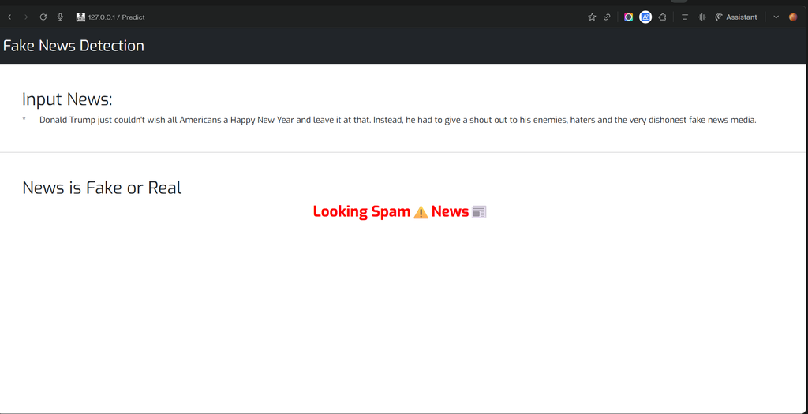

Figure 8.5: Web Application — Fake News Prediction

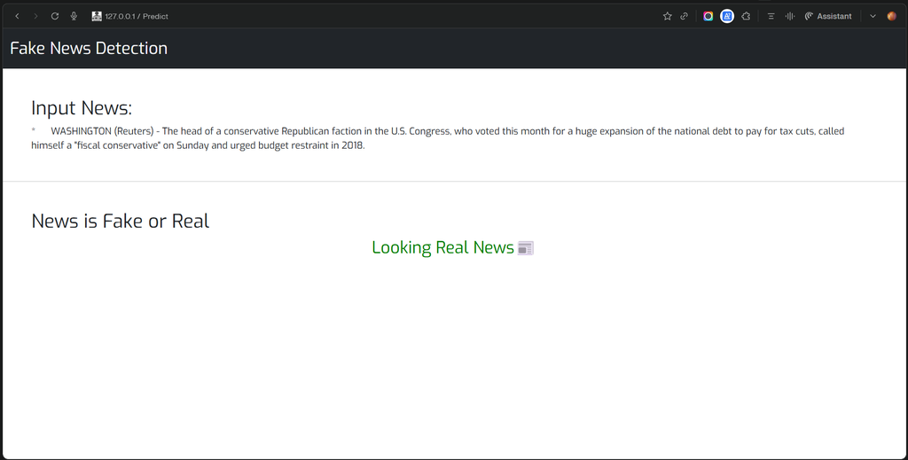

Figure 8.6: Web Application — Additional Test Output

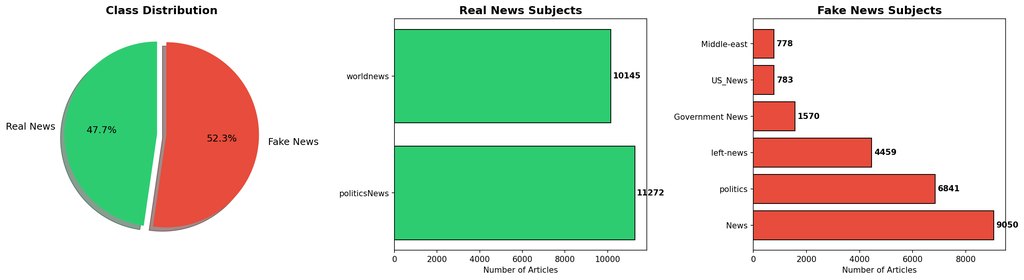

Figure 5.1: Dataset Distribution

[figure not shown]

Figure 8.1: Confusion Matrix

[figure not shown]

Figure 8.2: Model Comparison

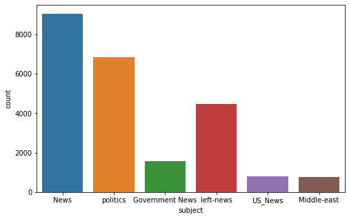

Figure 5.3: Fake Data Distribution